# Top Movies

Guillermo Hoyo Bravo

2 - 5 - 2022

# Inicialización

El siguiente código ha sido probado con R version 4.2.0 (2022-04-22 ucrt) y RStudio 1.2.240

Primeramente, es necesario cargar todas las bibliotecas que se van a emplear durante el proyecto.

```r
library(tidyverse)
library(cowplot)
library(hexbin)
library(lubridate)
library(scales)
library(dplyr)
library(stringr)
library(ggplot2)
require(gtable)


#theme_set(theme_cowplot(font_size=12)) # reduce default font size
```

# Carga y limpieza de datos

https://github.com/peetck/IMDB-Top1000-Movies/blob/master/IMDB-Movie-Data.csv

https://www.kaggle.com/datasets/PromptCloudHQ/imdb-data

```r
df <- read_csv("IMDB-Movie-Data.csv")
```

El *dataset* tiene los siguientes campos:

```r
colnames(df)
```

```
 [1] "Rank"               "Title"              "Genre"              "Description"        "Director"
 [6] "Actors"             "Year"               "Runtime (Minutes)"  "Rating"             "Votes"
[11] "Revenue (Millions)" "Metascore"
```

- **Rank**: Movie rank order
- **Title**: The title of the film
- **Genre**: A comma-separated list of genres used to classify the film
- **Description**: Brief one-sentence movie summary
- **Director**: The name of the film’s director
- **Actors**: A comma-separated list of the main stars of the film
- **Year**: The year that the film released as an integer.
- **Runtime(m)**: The duration of the film in minutes.
- **Rating**: User rating for the movie 0-10
- **Votes**: Number of votes
- **Revenue**: Movie revenue in millions
- **Metascore**: An aggregated average of critic scores. Values are between 0 and 100. Higher scores represent positive reviews.

# Limpiar registros con datos incorrectos

Comprobamos los Datos.

```r
summary(df)
```

```
      Rank           Title              Genre           Description          Director
 Min.   :   1.0   Length:1000        Length:1000        Length:1000        Length:1000
 1st Qu.: 250.8   Class :character   Class :character   Class :character   Class :character
 Median : 500.5   Mode  :character   Mode  :character   Mode  :character   Mode  :character
 Mean   : 500.5
 3rd Qu.: 750.2
 Max.   :1000.0
    Actors               Year      Runtime (Minutes)     Rating          Votes         Revenue (Millions)
 Length:1000        Min.   :2006   Min.   : 66.0     Min.   :1.900   Min.   :     61   Min.   :  0.000
 Class :character   1st Qu.:2010   1st Qu.:100.0     1st Qu.:6.200   1st Qu.:  36309   1st Qu.:  3.353
 Mode  :character   Median :2014   Median :111.0     Median :6.800   Median : 110799   Median : 37.145
                    Mean   :2013   Mean   :113.2     Mean   :6.723   Mean   : 169808   Mean   : 72.338
                    3rd Qu.:2016   3rd Qu.:123.0     3rd Qu.:7.400   3rd Qu.: 239910   3rd Qu.: 99.177
                    Max.   :2016   Max.   :191.0     Max.   :9.000   Max.   :1791916   Max.   :936.630
   Metascore
 Min.   : 11.00
 1st Qu.: 47.00
 Median : 59.00
 Mean   : 58.84
 3rd Qu.: 72.00
 Max.   :100.00
```

Para ello, tenemos que transformar el campo de Genre, del tipo character a un array donde se separan los diferentes generos que contiene una misma película. En este caso simplemento realizaremos una tabla contando cuantos generos hay individualmente.

```r
# Individualizamos los Generos
pei <- data.frame(table(str_split(df$Genre, ",", simplify = TRUE)))
#pei

# Limpiamos espacios en blanco
pei <- pei[-c(1), ]
pei
```

|  | Var1 | Freq |
| --- | --- | --- |
| 2 | Action | 303 |
| 3 | Adventure | 259 |
| 4 | Animation | 49 |
| 5 | Biography | 81 |
| 6 | Comedy | 279 |
| 7 | Crime | 150 |
| 8 | Drama | 513 |
| 9 | Family | 51 |
| 10 | Fantasy | 101 |
| 11 | History | 29 |

[output cut: 10 more lines]

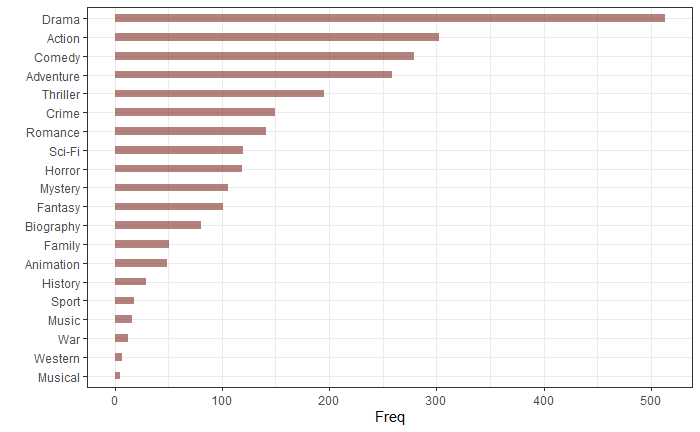

```r
# Ordenamos y Ploteamos Gráfico de Barras

pei %>%
  mutate(Var1 = fct_reorder(Var1, Freq)) %>%
  ggplot( aes(x=Var1, y=Freq)) +
    geom_bar(stat="identity", fill="#812F24", alpha=.6, width=.4) +
    coord_flip() +
    xlab("") +
    theme_bw()
```

```r
    #theme_set(theme_bw())
```

Gracias al gráfico, Llegamos a la conclusión de que los generos mas generados son:

```
1 - Drama

2 - Action

3 - Comedy
```

Y los menos generados:

[output not shown]

```r
# Vamos a separarlo por años
dosmilseis <- df[ which(df$Year=='2006'),]
dosmilseis
```

| Rank | Title | Genre | Description | Director | Actors | Year | Runtime (Minutes) | Rating | Votes | Revenue (Millions) | Metascore |
| --- | --- | --- | --- | --- | --- | --- | --- | --- | --- | --- | --- |
| 65 | The Prestige | Drama,Mystery,Sci-Fi | Two stage magicians engage in competitive one-upmanship in an attempt to create the ultimate stage illusion. | Christopher Nolan | Christian Bale, Hugh Jackman, Scarlett Johansson, Michael Caine | 2006 | 130 | 8.5 | 913152 | 53.08 | 66 |
| 79 | Pirates of the Caribbean: Dead Man's Chest | Action,Adventure,Fantasy | Jack Sparrow races to recover the heart of Davy Jones to avoid enslaving his soul to Jones' service, as other friends and foes seek the heart for their own agenda as well. | Gore Verbinski | Johnny Depp, Orlando Bloom, Keira Knightley, Jack Davenport | 2006 | 151 | 7.3 | 552027 | 423.03 | 53 |
| 100 | The Departed | Crime,Drama,Thriller | An undercover cop and a mole in the police attempt to identify each other while infiltrating an Irish gang in South Boston. | Martin Scorsese | Leonardo DiCaprio, Matt Damon, Jack Nicholson, Mark Wahlberg | 2006 | 151 | 8.5 | 937414 | 132.37 | 85 |
| 114 | 300 | Action,Fantasy,War | King Leonidas of Sparta and a force of 300 men fight the Persians at Thermopylae in 480 B.C. | Zack Snyder | Gerard Butler, Lena Headey, David Wenham, Dominic West | 2006 | 117 | 7.7 | 637104 | 210.59 | 52 |
| 165 | Casino Royale | Action,Adventure,Thriller | Armed with a licence to kill, Secret Agent James Bond sets out on his first mission as 007 and must defeat a weapons dealer in a high stakes game of poker at Casino Royale, but things are not what the… | Martin Campbell | Daniel Craig, Eva Green, Judi Dench, Jeffrey Wright | 2006 | 144 | 8.0 | 495106 | 167.01 | 80 |
| 222 | Cars | Animation,Adventure,Comedy | A hot-shot race-car named Lightning McQueen gets waylaid in Radiator Springs, where he finds the true meaning of friendship and family. | John Lasseter | Owen Wilson, Bonnie Hunt, Paul Newman, Larry the Cable Guy | 2006 | 117 | 7.1 | 283445 | 244.05 | 73 |
| 231 | Pan's Labyrinth | Drama,Fantasy,War | In the falangist Spain of 1944, the bookish young stepdaughter of a sadistic army officer escapes into an eerie but captivating fantasy world. | Guillermo del Toro | Ivana Baquero, Ariadna Gil, Sergi López,Maribel Verdú | 2006 | 118 | 8.2 | 498879 | 37.62 | 98 |
| 233 | Apocalypto | Action,Adventure,Drama | As the Mayan kingdom faces its decline, the rulers insist the key to prosperity is to build more temples and offer human sacrifices. Jaguar Paw, a young man captured for sacrifice, flees to avoid his … | Mel Gibson | Gerardo Taracena, Raoul Max Trujillo, Dalia Hernández,Rudy Youngblood | 2006 | 139 | 7.8 | 247926 | 50.86 | 68 |
| 247 | Children of Men | Drama,Sci-Fi,Thriller | In 2027, in a chaotic world in which women have become somehow infertile, a former activist agrees to help transport a miraculously pregnant woman to a sanctuary at sea. | Alfonso Cuarón | Julianne Moore, Clive Owen, Chiwetel Ejiofor,Michael Caine | 2006 | 109 | 7.9 | 382910 | 35.29 | 84 |
| 298 | The Devil Wears Prada | Comedy,Drama | A smart but sensible new graduate lands a job as an assistant to Miranda Priestly, the demanding editor-in-chief of a high fashion magazine. | David Frankel | Anne Hathaway, Meryl Streep, Adrian Grenier, Emily Blunt | 2006 | 109 | 6.8 | 302268 | 124.73 | 62 |

[output cut: 34 more lines]